# Análise e Projeção de Consumo de Energia com Modelagem de Equações Estruturais (SEM)

## Visão Geral

Este projeto demonstra uma aplicação de **Modelos de Equações Estruturais (SEM)** para análise e projeção de consumo de energia elétrica. A abordagem integra variáveis econômicas, demográficas e climáticas em um sistema complexo de equações simultâneas, permitindo capturar relações diretas e indiretas entre os fatores que influenciam o consumo energético.

### Objetivos do Projeto

- **Modelar relações complexas** entre indicadores econômicos e consumo de energia
- **Desenvolver capacidade preditiva** para projeções de consumo energético
- **Incorporar fatores sazonais e climáticos** na modelagem
- **Avaliar performance** através de métricas estatísticas robustas

## 1. Configuração do Ambiente

A primeira etapa garante a disponibilidade de todas as bibliotecas necessárias para a análise, utilizando o gerenciador de pacotes `pacman` para automatizar instalações e carregamentos.

```r
# Instala o pacman se ainda não estiver instalado
if (!require("pacman")) install.packages("pacman")
```

```r
# Carrega e instala automaticamente os pacotes listados, se necessário
pacman::p_load(DT, lavaan, tidyverse, readxl, plotly, lubridate, tidyr, glmnet,
               htmltools, gridExtra, htmlwidgets, visNetwork, tibble, funModeling
)
```

**Pacotes-chave utilizados:** - `lavaan`: Motor principal para Modelagem de Equações Estruturais - `tidyverse`: Ecosistema para manipulação e visualização de dados - `lubridate`: Manipulação eficiente de variáveis temporais - `readxl`: Interface para arquivos Excel

## 2. Carregamento e Inspeção dos Dados

```r
# Carregar os dados
dados <- read_excel("D:/OneDrive/Área de Trabalho/app_SEM/SEM/Dados.xlsx")

# visualizar primeiras linhas
print(head(dados))
```

```
## # A tibble: 6 × 11
##   data                consumo_energia    pib massa_renda   pim   pmc
##   <dttm>                        <dbl>  <dbl>       <dbl> <dbl> <dbl>
## 1 2005-01-01 00:00:00         280858. 12137. 4845571832.  57.2  33.9
## 2 2005-02-01 00:00:00         250830. 11261. 4941968745.  50.7  34.8
## 3 2005-03-01 00:00:00         281960. 11747. 5157974085.  57.4  39.7
## 4 2005-04-01 00:00:00         275840. 12336. 4983804789.  57.3  39.2
## 5 2005-05-01 00:00:00         285664. 13396. 5011743659.  59.2  41.6
## 6 2005-06-01 00:00:00         289363. 13896. 5262264933.  60.3  40.7
## # ℹ 5 more variables: indice_precos <dbl>, pop_domicilio <dbl>,
## #   temperatura <dbl>, precipitacao <dbl>, tarifa_energia <dbl>
```

Esta etapa inicial realiza a importação dos dados e uma verificação preliminar da estrutura, identificando potenciais inconsistências antes do processamento.

## 3. Engenharia de Variáveis e Pré-processamento

### Transformações Fundamentais

O pré-processamento é crucial para o sucesso do modelo SEM. Aplicamos múltiplas técnicas de engenharia de variáveis para capturar diferentes aspectos dos dados:

```r
dados_padronizados <- dados %>%
  mutate(Date = as.Date(data)) %>%
  arrange(Date) %>%
  mutate(
    trend = row_number(),
    trend_scaled = scale(trend)[,1],

    # Log-transformações
    log_PIB = log(pib),
    log_MassaRenda = log(massa_renda),
    log_PIM = log(pim),
    log_PMC = log(pmc),
    log_ConsumoEnergia = ifelse(is.na(consumo_energia), NA, log(consumo_energia)),
    log_IPCA = log(indice_precos),
    log_Populacao = log(pop_domicilio),
    log_Temperatura = log(temperatura),
    log_Chuva = log(precipitacao + 1), # evita log(0)
    log_PrecoEnergia = log(tarifa_energia),

    # Sazonalidade e interações
    mes = month(data),
    dia = day(data),
    sin1 = sin(2 * pi * mes / 12),
    cos1 = cos(2 * pi * mes / 12),
    sin2 = sin(4 * pi * mes / 12),
    cos2 = cos(4 * pi * mes / 12),
    temp_sin1 = log_Temperatura * sin(2 * pi * mes / 12),
    temp_cos1 = log_Temperatura * cos(2 * pi * mes / 12),

    # Dummies sazonais e climáticas
    verao = mes %in% c(12, 1, 2, 3),
    inverno = mes %in% c(6, 7, 8, 9),
    bro_bro = mes %in% c(9, 10, 11, 12),
    d_quente = as.integer(log_Temperatura > mean(log_Temperatura, na.rm = TRUE) + 0.5 * sd(log_Temperatura, na.rm = TRUE)),
    d_frio = as.integer(log_Temperatura < mean(log_Temperatura, na.rm = TRUE) - 0.5 * sd(log_Temperatura, na.rm = TRUE)),

    dummy_pandemia = as.integer(Date >= as.Date("2020-01-01") & Date <= as.Date("2023-01-01")),

    # Período da crise do impeachment da Dilma (aproximadamente, de Dezembro de 2015 a Agosto de 2016)
    dummy_crises = as.integer(Date >= as.Date("2015-01-01") & Date <= as.Date("2018-01-01"))
  )


# Criar variáveis dummy para os meses (1 a 12)
for (m in 1:12) {
  coluna_mes <- paste0("mes_", m)
  dados_padronizados[[coluna_mes]] <- as.integer(dados_padronizados$mes == m)
}
```

### Estratégias de Transformação Implementadas

**📈 Transformações Logarítmicas** - Normalização de distribuições assimétricas - Estabilização da variância - Interpretação elasticidade entre variáveis

**🔄 Componentes Sazonais** - Funções trigonométricas (seno/cosseno) para capturar ciclos anuais - Variáveis dummy mensais para efeitos discretos - Termos de interação temperatura-sazonalidade

**🌡️ Variáveis Climáticas** - Classificação de períodos extremos (quente/frio) - Dummies sazonais (verão, inverno) - Variáveis de precipitação tratadas para evitar log(0)

**📅 Controles Temporais** - Tendência linear e padronizada - Dummies para eventos estruturais (pandemia, crises políticas)

## 4. Divisão Temporal dos Dados

```r
# Data até onde os dados são de treino
data_corte <- as.Date("2024-07-01")

# Definir dados de treino
dados_treinamento <- dados_padronizados %>%
  filter(Date <= data_corte, !is.na(log_ConsumoEnergia))

# Definir dados de projeção
dados_projecao <- dados_padronizados %>%
  filter(Date > data_corte)
```

## 5. Especificação do Modelo SEM

### Arquitetura do Sistema de Equações

O modelo SEM captura a estrutura causal complexa entre as variáveis econômicas e o consumo de energia através de um sistema hierárquico de equações:

```r
modelo_sem <- '
  # PIB
  log_PIB ~ log_IPCA + log_Populacao + trend_scaled + sin1 + cos1 + sin2 + cos2 + dummy_pandemia + dummy_crises

  # Massa de Renda
  log_MassaRenda ~ log_Populacao + log_IPCA + log_PIB + trend_scaled + sin1 + cos1 + sin2 + cos2 + dummy_pandemia + dummy_crises

  # PIM
  log_PIM ~ log_PIB  + trend_scaled  + sin1 + cos1 + sin2 + cos2 + dummy_pandemia + dummy_crises

  # PMC
  log_PMC ~ log_PIB + log_MassaRenda + trend_scaled + sin1 + cos1 + sin2 + cos2 + dummy_pandemia + dummy_crises

  # Consumo de Energia
  log_ConsumoEnergia ~ log_PIB + log_PIM + log_PMC + log_MassaRenda +
                        log_Temperatura + log_PrecoEnergia +
                        trend_scaled + sin1 + cos1 + sin2 + cos2 +
                        d_quente + d_frio + bro_bro + dummy_pandemia + dummy_crises
'

# Estimar o modelo
fit_sem <- sem(modelo_sem, data = dados_treinamento, missing = "fiml")
```

### Estrutura Causal do Modelo

**Nível 1 - Fundamentos Macroeconômicos** - PIB como função de inflação, população e tendências

**Nível 2 - Indicadores Intermediários**  
- Massa de Renda influenciada pelo PIB e variáveis macroeconômicas - PIM (Produção Industrial) conectado ao PIB - PMC (Comércio) dependente de PIB e Massa de Renda

**Nível 3 - Consumo de Energia (Variável Target)** - Função de todos os indicadores econômicos anteriores - Incorporação de fatores climáticos e preços de energia - Controles sazonais e estruturais

**Vantagens da Abordagem SEM:** - ✅ Captura efeitos diretos e indiretos simultaneamente - ✅ Trata endogeneidade entre variáveis econômicas  
- ✅ Permite decomposição de efeitos causais - ✅ Método FIML robusto para dados ausentes

## 6. Diagrama do SEM

```r
# Definir nós do diagrama
nodes <- data.frame(
  id = c("IPCA", "Populacao", "Temperatura", "Chuva", "PrecoEnergia", "Trend", "Sazonais", "dummies",
         "PIB", "MassaRenda", "PIM", "PMC", "ConsumoEnergia"),
  label = c("IPCA", "População", "Temperatura", "Chuva", "Preço Energia", "Tendência", "Sazonais", "Dummies",
            "PIB", "Massa Renda", "PIM", "PMC", "Consumo Energia"),
  group = c(rep("Exógenas", 5), rep("Temporais", 2), "Exógenas",  # 'dummies' como exógena
            rep("Endógenas", 5)),
  level = c(rep(1, 8), 2, 2, 3, 3, 4),  # 'dummies' no mesmo nível das exógenas
  color = c(rep("#FF6B6B", 6), "#4ECDC4", "#4ECDC4",  # exógenas e temporais
            rep("#45B7D1", 3), "#96CEB4", "#FFEAA7")  # endógenas com cores distintas
)

# Definir arestas (relações causais)
edges <- data.frame(
  from = c("IPCA", "Trend", "Sazonais", "dummies",  # Para PIB
           "Populacao", "IPCA", "PIB", "Trend", "Sazonais", "dummies", # Para MassaRenda
           "PIB", "Trend", "Sazonais", "dummies", # Para PIM
           "PIB", "MassaRenda", "Trend", "Sazonais", "dummies", # Para PMC
           "PIB", "PIM", "PMC", "MassaRenda", "Temperatura", "Chuva", "PrecoEnergia", "Trend", "Sazonais", "dummies"),  # Para ConsumoEnergia
  to = c(rep("PIB", 4),
         rep("MassaRenda", 6),
         rep("PIM", 4),
         rep("PMC", 5),
         rep("ConsumoEnergia", 10)),
  arrows = "to",
  color = "#666666",
  width = 2
)

# Criar diagrama interativo SEM (sem "mola")
diagrama_sem <- visNetwork(nodes, edges, height = "600px", width = "100%") %>%
  visGroups(groupname = "Exógenas", color = "#FF6B6B", shape = "box") %>%
  visGroups(groupname = "Temporais", color = "#4ECDC4", shape = "ellipse") %>%
  visGroups(groupname = "Endógenas", color = "#45B7D1", shape = "diamond") %>%
  visLegend(width = 0.2, position = "right") %>%
  visLayout(randomSeed = 123, hierarchical = list(enabled = TRUE, direction = "UD", sortMethod = "directed")) %>%
  visOptions(highlightNearest = TRUE, nodesIdSelection = TRUE) %>%
  visInteraction(navigationButtons = TRUE) %>%
  visEdges(arrows = "to", color = list(color = "#666666", highlight = "#FF0000")) %>%
  visPhysics(enabled = FALSE)

# Salvar diagrama como HTML
# saveWidget(diagrama_sem, "diagrama_sem_energia.html", selfcontained = TRUE)
# cat("Diagrama SEM salvo como 'diagrama_sem_energia.html'\n")

# Mostrar diagrama
diagrama_sem
```

[interactive chart not shown]

## 7. Função de Previsão Customizada

### Implementação da Engine de Predição

```r
# Obter os coeficientes padronizados ou não
coeficientes <- parameterEstimates(fit_sem)

prever_variavel_sem <- function(modelo_sem, dados_novos, variavel_destino) {
  # Extrair coeficientes das variáveis explicativas
  coefs <- parameterEstimates(modelo_sem) %>%
    filter(lhs == variavel_destino & op == "~") %>%
    select(rhs, est)

  # Extrair intercepto (se existir)
  intercepto <- parameterEstimates(modelo_sem) %>%
    filter(lhs == variavel_destino & op == "~1") %>%
    pull(est)

  if (length(intercepto) == 0) intercepto <- 0  # caso não tenha intercepto

  # Verificar se todas as variáveis estão nos dados
  faltantes <- setdiff(coefs$rhs, names(dados_novos))
  if (length(faltantes) > 0) {
    stop(paste("Variáveis ausentes nos dados:", paste(faltantes, collapse = ", ")))
  }

  # Calcular a predição como soma ponderada + intercepto
  previsao <- rowSums(
    sapply(coefs$rhs, function(var) {
      dados_novos[[var]] * coefs$est[coefs$rhs == var]
    }), na.rm = TRUE
  ) + intercepto

  return(previsao)
}
```

Esta função personalizada extrai automaticamente os coeficientes estimados do modelo SEM e aplica a combinação linear para gerar previsões, oferecendo flexibilidade para prever qualquer variável endógena do sistema.

## 8. Geração de Projeções

```r
dados_projecao$log_ConsumoEnergia_prevista <- prever_variavel_sem(
  modelo_sem = fit_sem,
  dados_novos = dados_projecao,
  variavel_destino = "log_ConsumoEnergia"
)

# Juntar os dados de treino e projeção com a variável observada e a prevista
resultados <- dados_padronizados %>%
  select(Date, log_ConsumoEnergia) %>%
  left_join(
    dados_projecao %>%
      select(Date, log_ConsumoEnergia_prevista),
    by = "Date"
  ) %>%
  mutate(
    ConsumoEnergia_real = exp(log_ConsumoEnergia),
    ConsumoEnergia_prevista = exp(log_ConsumoEnergia_prevista)
  )
```

As projeções são geradas aplicando os coeficientes estimados aos dados futuros, com transformação inversa (exponencial) para retornar à escala original dos dados.

## 9. Avaliação de Performance

### Métrica MAPE (Mean Absolute Percentage Error)

```r
# Prever log_ConsumoEnergia nos dados de treino
dados_treinamento$log_ConsumoEnergia_prevista <- prever_variavel_sem(
  modelo_sem = fit_sem,
  dados_novos = dados_treinamento,
  variavel_destino = "log_ConsumoEnergia"
)

# Calcular valores reais e previstos na escala original
dados_treinamento <- dados_treinamento %>%
  mutate(
    ConsumoEnergia_real = exp(log_ConsumoEnergia),
    ConsumoEnergia_prevista = exp(log_ConsumoEnergia_prevista)
  )

# Últimos 12 meses antes da data de corte
dados_mape <- dados_treinamento %>%
  filter(Date > (data_corte %m-% months(6)), Date <= data_corte)

# Calcular MAPE
mape <- mean(abs((dados_mape$ConsumoEnergia_real - dados_mape$ConsumoEnergia_prevista) / dados_mape$ConsumoEnergia_real), na.rm = TRUE) * 100

# Exibir
cat("MAPE dos últimos 12 meses antes da previsão:", round(mape, 2), "%\n")
```

```
## MAPE dos últimos 12 meses antes da previsão: 1.78 %
```

O MAPE é calculado nos últimos 6 meses do período de treinamento, fornecendo uma métrica interpretável (em percentual) da acurácia preditiva do modelo em dados quasi-out-of-sample.

## 10. Visualização dos Resultados

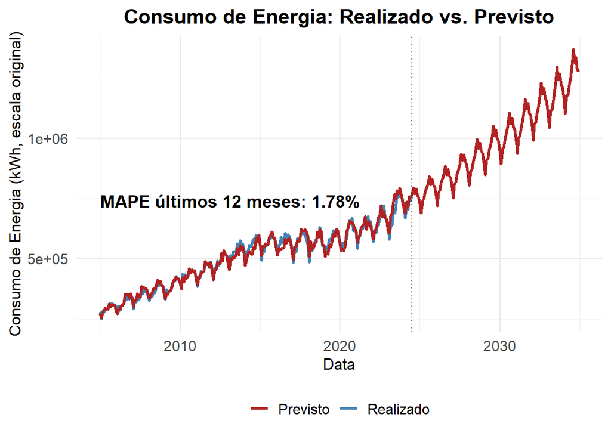

```r
# Unir os conjuntos (mantém a mesma lógica de antes)
resultados_completos <- bind_rows(
  dados_treinamento %>% select(Date, ConsumoEnergia_real, ConsumoEnergia_prevista),
  dados_projecao %>%
    mutate(
      ConsumoEnergia_real = NA, # Valores reais são NA para o período de projeção
      ConsumoEnergia_prevista = exp(log_ConsumoEnergia_prevista) # Transforma para a escala original
    ) %>%
    select(Date, ConsumoEnergia_real, ConsumoEnergia_prevista)
)


library(ggplot2)

ggplot(resultados_completos, aes(x = Date)) +
  # Linhas de série real e prevista
  geom_line(aes(y = ConsumoEnergia_real, color = "Realizado"), size = 1.2, na.rm = TRUE) +
  geom_line(aes(y = ConsumoEnergia_prevista, color = "Previsto"), size = 1.2, na.rm = TRUE) +

  # Linha vertical indicando início da projeção
  geom_vline(xintercept = as.numeric(data_corte), linetype = "dotted", color = "black") +

  # Anotação da linha de corte
  annotate("text",
           x = data_corte,
           y = Inf,
           label = "Início da Projeção",
           vjust = -0.5,
           hjust = -0.1,
           size = 4.5,
           fontface = "italic") +

  # Anotação do MAPE
  annotate("text",
           x = min(resultados_completos$Date, na.rm = TRUE),
           y = max(resultados_completos$ConsumoEnergia_real, na.rm = TRUE),
           label = paste0("MAPE últimos 12 meses: ", round(mape, 2), "%"),
           hjust = 0,
           vjust = 1.5,
           size = 5,
           color = "black",
           fontface = "bold") +

  # Títulos e eixos
  labs(
    title = "Consumo de Energia: Realizado vs. Previsto",
    y = "Consumo de Energia (kWh, escala original)",
    x = "Data",
    color = NULL  # Remove o título da legenda ("color")
  ) +

  # Cores definidas manualmente
  scale_color_manual(values = c("Realizado" = "steelblue", "Previsto" = "firebrick")) +

  # Tema minimalista com ajustes
  theme_minimal(base_size = 14) +
  theme(
    legend.position = "bottom",       # Legenda abaixo do gráfico
    legend.title = element_blank(),   # Remove o título da legenda
    plot.title = element_text(face = "bold", hjust = 0.5),  # Centraliza o título
    legend.text = element_text(size = 12),
    axis.text = element_text(size = 12),
    axis.title = element_text(size = 13)
  )
```

## Limitações e Considerações Metodológicas

### Limitações da Modelagem SEM para Projeções

Embora os Modelos de Equações Estruturais ofereçam vantagens significativas para capturar relações complexas, é importante reconhecer suas limitações específicas no contexto de projeções de séries temporais:

#### 🔴 **Limitações Estruturais**

**1. Suposições de Linearidade** - SEM assume relações lineares entre variáveis, o que pode não capturar adequadamente dinâmicas não-lineares complexas do consumo de energia - Mudanças estruturais abruptas no sistema energético podem não ser bem modeladas

**2. Estabilidade Temporal dos Parâmetros** - O modelo assume que as relações entre variáveis permanecem constantes ao longo do tempo - Mudanças regulatórias, tecnológicas ou comportamentais podem alterar fundamentalmente essas relações

**3. Propagação de Erros** - Em sistemas de equações simultâneas, erros de estimação se propagam através da cadeia causal - Pequenos erros em variáveis econômicas fundamentais podem resultar em grandes desvios nas projeções finais

#### 🔴 **Limitações Específicas para Projeções**

**4. Dependência de Variáveis Exógenas** - A qualidade das projeções depende criticamente da disponibilidade e acurácia das variáveis explicativas futuras - PIB, população, preços - todas requerem suas próprias projeções, adicionando incerteza cumulativa

**5. Ausência de Mecanismos de Correção** - Diferentemente de modelos de séries temporais puros (ARIMA, VAR), SEM não incorpora mecanismos de correção de erro automáticos - Não há ajuste dinâmico baseado em desvios observados

**6. Sensibilidade a Quebras Estruturais** - Eventos como crises energéticas, mudanças de matriz energética ou políticas climáticas podem invalidar completamente as relações modeladas - O modelo pode falhar em períodos de transformação estrutural

#### 🔴 **Limitações Técnicas**

**7. Identificação e Causalidade** - Embora SEM permita testar hipóteses causais, a identificação de relações verdadeiramente causais depende de suposições teóricas que podem ser violadas - Variáveis omitidas podem confundir as relações estimadas

**8. Multicolinearidade em Sistemas Complexos** - Variáveis econômicas frequentemente exibem alta correlação, complicando a identificação de efeitos individuais - Pode levar a instabilidade nos coeficientes estimados

#### ⚡ **Alternativas Complementares**

Para mitigar essas limitações, seria recomendável considerar:

- **Modelos híbridos** combinando SEM com métodos de séries temporais
- **Abordagens de machine learning** para capturar não-linearidades
- **Modelos de mudança de regime** para lidar com quebras estruturais
- **Métodos ensemble** combinando múltiplas abordagens de modelagem
- **Intervalos de confiança robustos** através de bootstrap ou simulação

#### 📊 **Contexto de Aplicação**

O SEM é mais apropriado para: - ✅ Análise de relações estruturais entre variáveis - ✅ Projeções de médio prazo em ambientes estáveis - ✅ Decomposição de efeitos causais - ✅ Cenários com boa disponibilidade de variáveis explicativas

E menos adequado para: - ❌ Projeções de muito longo prazo - ❌ Períodos de alta volatilidade ou mudança estrutural - ❌ Situações com dados limitados de variáveis explicativas - ❌ Quando a precisão pontual é crítica

## Conclusão

Este projeto demonstra uma aplicação sofisticada de Modelagem de Equações Estruturais para análise de consumo energético, integrando múltiplas dimensões (econômica, climática, temporal) em um framework estatístico robusto. A abordagem oferece insights valiosos sobre as relações estruturais subjacentes, embora deva ser utilizada com consciência de suas limitações metodológicas para aplicações de projeção.

**Principais Contribuições:** - Framework integrado para modelagem multi-dimensional de consumo energético - Implementação robusta de SEM com tratamento de dados ausentes - Sistema de avaliação quantitativa de performance preditiva - Código modular e reutilizável para análises similares

Este trabalho representa uma síntese entre rigor metodológico e aplicabilidade prática, adequado para contextos de planejamento energético onde a compreensão das relações estruturais é tão importante quanto a capacidade preditiva.